# Chapter 3

Hanna Haltia

2023-11-20

# Assignment 3 - Logistic regression

The data of this assignment has been collected from two Portuguese schools, and regards the performance of students in both Portuguese language, and mathematics. In addition to the school performance, the dataset contains information about the students (age, sex, alcohol use) and about the socioeconomic factors related to the students (education of their parents). The data contains 370 observations and 35 variables.

Let’s start by reading in the data.

```r
suppressMessages(library(readr))
alc <- read_csv("/Users/hchaltia/Open data science course/IODS-project/data/alc_dataset.csv")
```

For the sake of this assignment, I will choose sex, age, mother’s education, and father’s education as the independent variables. The model will study the association of these variables to the high/low alcohol usage variable. My hypothesis is that male sex, higher age, and lower parents’ education level associates to higher alcohol consumption.

Let’s explore these variables with numerical and graphical presentations.

```r
# Load needed packages
suppressMessages(library(ggplot2))
suppressMessages(library(GGally))
suppressMessages(library(tidyverse))

# Create an analysis dataset with only the chosen variables and explore its dimensions
alc_analysis <- alc %>% select(age, sex, Medu, Fedu, high_use)
str(alc_analysis)
```

```
## tibble [370 × 5] (S3: tbl_df/tbl/data.frame)
##  $ age     : num [1:370] 18 17 15 15 16 16 16 17 15 15 ...
##  $ sex     : chr [1:370] "F" "F" "F" "F" ...
##  $ Medu    : num [1:370] 4 1 1 4 3 4 2 4 3 3 ...
##  $ Fedu    : num [1:370] 4 1 1 2 3 3 2 4 2 4 ...
##  $ high_use: logi [1:370] FALSE FALSE TRUE FALSE FALSE FALSE ...
```

```r
# Convert Medu and Fedu into factors
alc_analysis$Medu <- as.factor(alc_analysis$Medu)
alc_analysis$Fedu <- as.factor(alc_analysis$Fedu)
str(alc_analysis)
```

```
## tibble [370 × 5] (S3: tbl_df/tbl/data.frame)
##  $ age     : num [1:370] 18 17 15 15 16 16 16 17 15 15 ...
##  $ sex     : chr [1:370] "F" "F" "F" "F" ...
##  $ Medu    : Factor w/ 5 levels "0","1","2","3",..: 5 2 2 5 4 5 3 5 4 4 ...
##  $ Fedu    : Factor w/ 5 levels "0","1","2","3",..: 5 2 2 3 4 4 3 5 3 5 ...
##  $ high_use: logi [1:370] FALSE FALSE TRUE FALSE FALSE FALSE ...
```

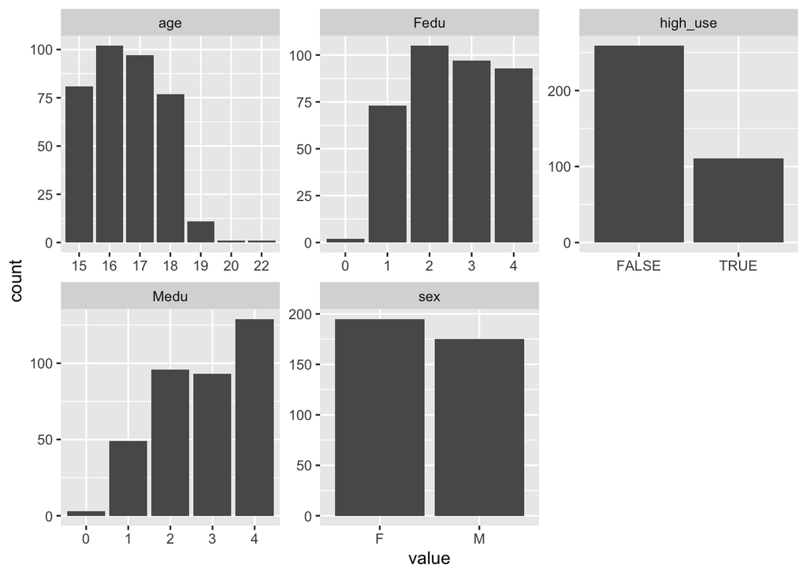

```r
# Draw a bar plot of each variable
gather(alc_analysis) %>% ggplot(aes(value)) + facet_wrap("key", scales = "free") + geom_bar()
```

Based on the bar plots, the age distribution of the students is, not surprisingly, skewed towards 15-18 years with a few older students recorded as well. There are slightly more females than males, and majority of the students do not have high alcohol use. In both mothers and fathers, level 0 education is very uncommon.

Let’s draw some more plots to explore the relationships of the variables.

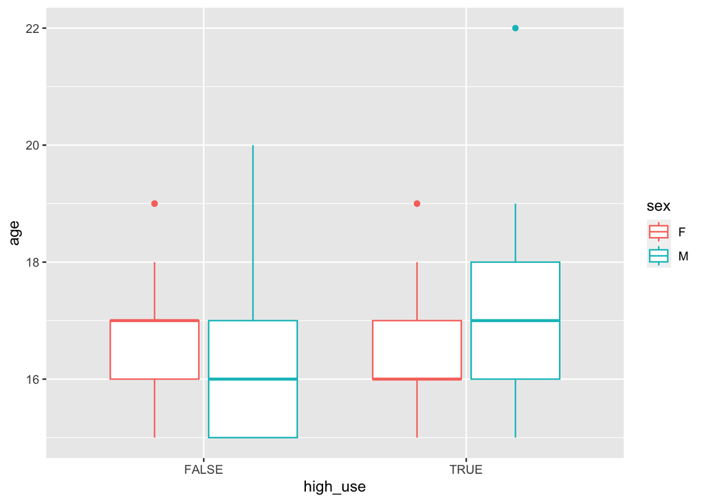

```r
# Initialize a plot of high_use and age
g1 <- ggplot(alc_analysis, aes(high_use, age, col = sex))

# Define the plot as a boxplot and draw it
g1 + geom_boxplot() + ylab("age")
```

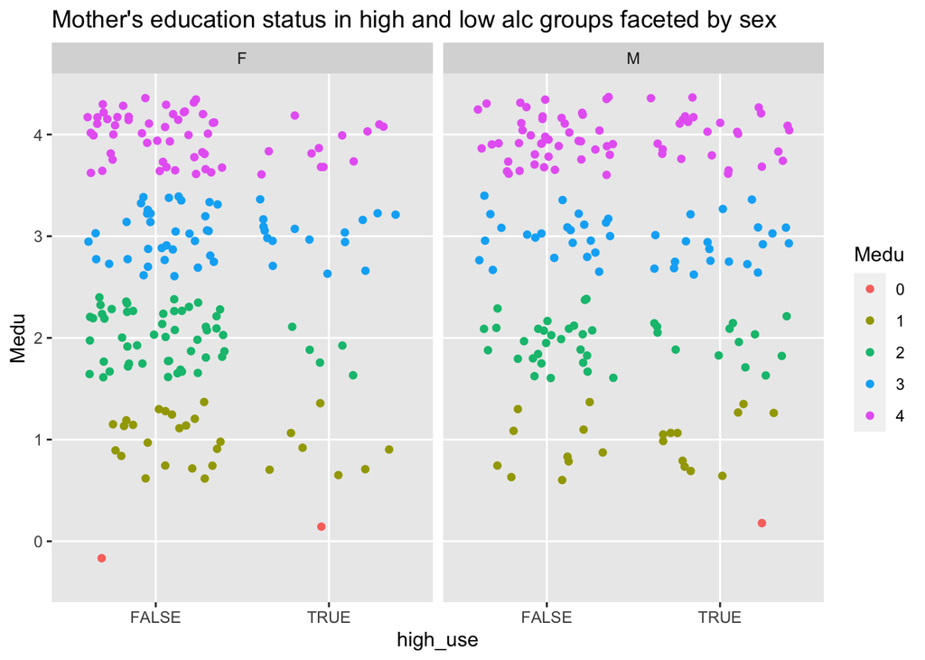

```r
# Plot mother's education against high_use
ggplot(alc_analysis, aes(high_use, Medu, col = Medu)) + geom_point(position = "jitter") + facet_wrap("sex") +
  ggtitle("Mother's education status in high and low alc groups faceted by sex")
```

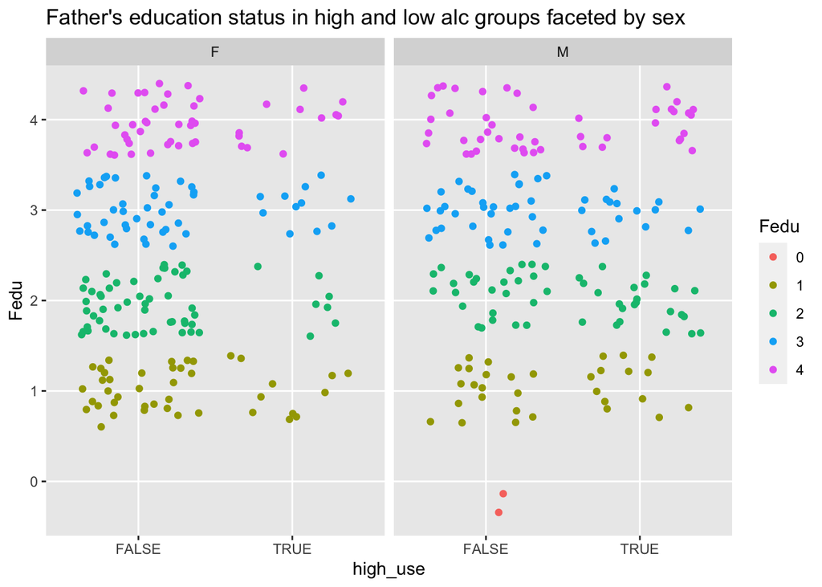

```r
# Plot father's education against high_use
ggplot(alc_analysis, aes(high_use, Fedu, col = Fedu)) + geom_point(position = "jitter") + facet_wrap("sex") +
  ggtitle("Father's education status in high and low alc groups faceted by sex")
```

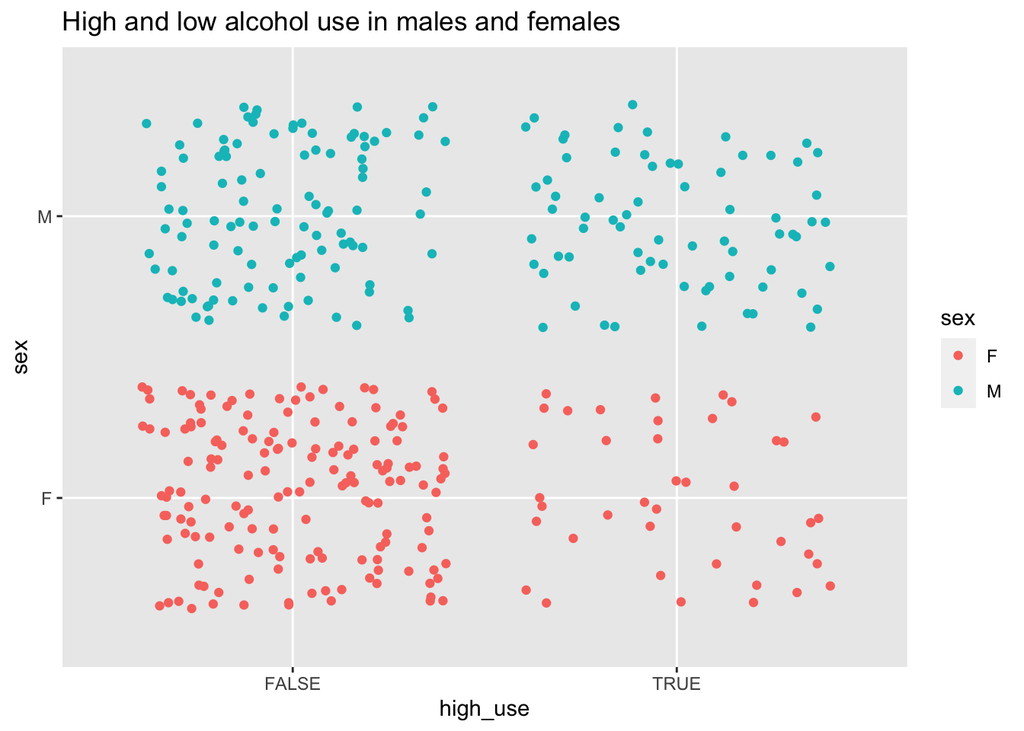

```r
# Initialize a plot of high_use and sex
ggplot(alc_analysis, aes(high_use, sex, col = sex)) + geom_point(position = "jitter") +
  ggtitle("High and low alcohol use in males and females")
```

Based on the first boxplot, it looks like in males the high alcohol consumption group is on average older than the low use group, which does not seem a strong phenomenon visible in females. In females, mother’s level 2 education seems to have less high alcohol users, whereas in males this is not true. The same level 2 education phenomenon is visible in females also in terms of father’s education, but not in males. Based on the last plot, it looks like high alcohol use is more common in males. Thus, the hypotheses about age and sex seem to be promising, but not so much the initial education hypothesis.

Let’s still look at some numerical summary values.

```r
# Produce summary statistics by group
alc_analysis %>% group_by(sex, high_use) %>% summarise(count = n(), mean_age = mean(age))
```

[output not shown]

```
## # A tibble: 4 × 4
## # Groups:   sex [2]
##   sex   high_use count mean_age
##   <chr> <lgl>    <int>    <dbl>
## 1 F     FALSE      154     16.6
## 2 F     TRUE        41     16.5
## 3 M     FALSE      105     16.3
## 4 M     TRUE        70     16.9
```

Looking at the table, it is indeed more common in males to belong in the high alcohol use group. Mean ages of the groups are not very different examined this way.

Next, let’s fit a logistic regression model on the data using the chosen variables. I want to compare other education levels to the highest education level, so let’s first relevel the factors to have education level 4 as the reference.

```r
# Relevel mother and father's education variables to have education level 4 as the reference value
alc_analysis <- within(alc_analysis, Medu <- relevel(Medu, ref = 5))
alc_analysis <- within(alc_analysis, Fedu <- relevel(Fedu, ref = 5))

# Fit the model
m <- glm(high_use ~ Medu + Fedu + sex + age, data = alc_analysis, family = "binomial")
m2 <- glm(high_use ~ Medu + sex + age, data = alc_analysis, family = "binomial")
m3 <- glm(high_use ~ Fedu + sex + age, data = alc_analysis, family = "binomial")
m4 <- glm(high_use ~ sex + age, data = alc_analysis, family = "binomial")

# Print a summary of the model
summary(m)
```

```
##
## Call:
## glm(formula = high_use ~ Medu + Fedu + sex + age, family = "binomial",
##     data = alc_analysis)
##
## Coefficients:
##              Estimate Std. Error z value Pr(>|z|)
## (Intercept)  -4.08975    1.69359  -2.415   0.0157 *
## Medu0         1.70131    1.28951   1.319   0.1871
## Medu1         0.44254    0.47222   0.937   0.3487
## Medu2        -0.49006    0.39917  -1.228   0.2196
## Medu3         0.53865    0.32453   1.660   0.0970 .
## Fedu0       -14.28418  614.68104  -0.023   0.9815
## Fedu1        -0.08473    0.45649  -0.186   0.8527
## Fedu2        -0.13582    0.38138  -0.356   0.7218
## Fedu3        -0.34310    0.34689  -0.989   0.3226
## sexM          0.98711    0.24232   4.074 4.63e-05 ***
## age           0.16674    0.10212   1.633   0.1025
## ---
## Signif. codes:  0 '***' 0.001 '**' 0.01 '*' 0.05 '.' 0.1 ' ' 1
##
## (Dispersion parameter for binomial family taken to be 1)
##
##     Null deviance: 452.04  on 369  degrees of freedom
## Residual deviance: 416.96  on 359  degrees of freedom
## AIC: 438.96
##
## Number of Fisher Scoring iterations: 13
```

```r
summary(m2)
```

```
##
## Call:
## glm(formula = high_use ~ Medu + sex + age, family = "binomial",
##     data = alc_analysis)
##
## Coefficients:
##             Estimate Std. Error z value Pr(>|z|)
## (Intercept)  -4.2774     1.6761  -2.552   0.0107 *
## Medu0         1.7052     1.2610   1.352   0.1763
## Medu1         0.4069     0.3712   1.096   0.2730
## Medu2        -0.5040     0.3337  -1.510   0.1310
## Medu3         0.4869     0.3003   1.622   0.1049
## sexM          0.9611     0.2411   3.987 6.69e-05 ***
## age           0.1709     0.1007   1.698   0.0895 .
## ---
## Signif. codes:  0 '***' 0.001 '**' 0.01 '*' 0.05 '.' 0.1 ' ' 1
##
## (Dispersion parameter for binomial family taken to be 1)
##
##     Null deviance: 452.04  on 369  degrees of freedom
## Residual deviance: 420.11  on 363  degrees of freedom
## AIC: 434.11
##
## Number of Fisher Scoring iterations: 4
```

```r
summary(m3)
```

```
##
## Call:
## glm(formula = high_use ~ Fedu + sex + age, family = "binomial",
##     data = alc_analysis)
##
## Coefficients:
##              Estimate Std. Error z value Pr(>|z|)
## (Intercept)  -4.48890    1.66806  -2.691  0.00712 **
## Fedu0       -14.09651  623.22338  -0.023  0.98195
## Fedu1        -0.02766    0.35030  -0.079  0.93706
## Fedu2        -0.19495    0.31899  -0.611  0.54111
## Fedu3        -0.26825    0.32673  -0.821  0.41165
## sexM          0.95384    0.23641   4.035 5.47e-05 ***
## age           0.19766    0.10010   1.975  0.04831 *
## ---
## Signif. codes:  0 '***' 0.001 '**' 0.01 '*' 0.05 '.' 0.1 ' ' 1
##
## (Dispersion parameter for binomial family taken to be 1)
##
##     Null deviance: 452.04  on 369  degrees of freedom
## Residual deviance: 429.07  on 363  degrees of freedom
## AIC: 443.07
##
## Number of Fisher Scoring iterations: 13
```

```r
summary(m4)
```

```
##
## Call:
## glm(formula = high_use ~ sex + age, family = "binomial", data = alc_analysis)
##
## Coefficients:
##             Estimate Std. Error z value Pr(>|z|)
## (Intercept) -4.72614    1.65095  -2.863   0.0042 **
## sexM         0.93259    0.23552   3.960 7.51e-05 ***
## age          0.20425    0.09812   2.082   0.0374 *
## ---
## Signif. codes:  0 '***' 0.001 '**' 0.01 '*' 0.05 '.' 0.1 ' ' 1
##
## (Dispersion parameter for binomial family taken to be 1)
##
##     Null deviance: 452.04  on 369  degrees of freedom
## Residual deviance: 431.73  on 367  degrees of freedom
## AIC: 437.73
##
## Number of Fisher Scoring iterations: 4
```

Based on the model iterations, mother’s and father’s education levels do not seem to be significant predictors, so let’s continue with sex and age.

Let’s look at the resulting odds ratios and confidence intervals based on the model coefficients.

```r
# Compute odds ratios (OR)
OR <- coef(m4) %>% exp

# Compute confidence intervals (CI)
CI <- confint(m4) %>% exp()
# Print out the odds ratios with their confidence intervals
cbind(OR, CI)
```

```
##                      OR        2.5 %    97.5 %
## (Intercept) 0.008860572 0.0003296194 0.2173513
## sexM        2.541071530 1.6088411176 4.0567456
## age         1.226598777 1.0134340303 1.4905305
```

Male sex and age both were significant predictors in the model, and their confidence intervals do not include value 1, which would be a sign of insignificance.

In the next part, let’s prepare a cross tabulation using the model predictions.

```r
suppressMessages(library(dplyr))

# Predict() the probability of high_use
probabilities <- predict(m4, type = "response")

# Add the predicted probabilities to alc_analysis
alc_analysis <- mutate(alc_analysis, probability = probabilities)

# Use the probabilities to make a prediction of high_use
alc_analysis <- mutate(alc_analysis, prediction = probability > 0.5)

# Tabulate the target variable versus the predictions
table(high_use = alc_analysis$high_use, prediction = alc_analysis$prediction)
```

```
##         prediction
## high_use FALSE TRUE
##    FALSE   254    5
##    TRUE    108    3
```

Let’s compute the total proportion of inaccurately classified individuals.

```r
# Define a loss function (mean prediction error)
loss_func <- function(class, prob) {
  n_wrong <- abs(class - prob) > 0.5
  mean(n_wrong)
}

# Call loss_func to compute the average number of wrong predictions in the (training) data
loss_func(class = alc_analysis$high_use, prob = alc_analysis$probability)
```

```
## [1] 0.3054054
```

The mean prediction error is about 0.31. Looking at the cross-tabulation, the model is pretty bad at predicting, because almost all true high users are categorized as non-high users. Based on the model quality assessment, the chosen variables are not adequate at predicting high alcohol use.

Let’s try the 10-fold cross-validation on the model.

```r
# Define a loss function (mean prediction error)
loss_func <- function(class, prob) {
  n_wrong <- abs(class - prob) > 0.5
  mean(n_wrong)
}

# K-fold cross-validation
library(boot)
cv <- cv.glm(data = alc_analysis, cost = loss_func, glmfit = m4, K = 10)

# average number of wrong predictions in the cross validation
cv$delta[1]
```

```
## [1] 0.3243243
```

The cross validation does not seem to give any better results than the originally used method.